# TBD

## Correlations

Now that we’ve concluded our univariate data analysis and data cleaning, we can begin exploratory analysis into correlations. This will give us an idea of what to expect from our models. Since so many of our predictors are categorical and our response is numeric, we’ll make heavy use of boxplots.

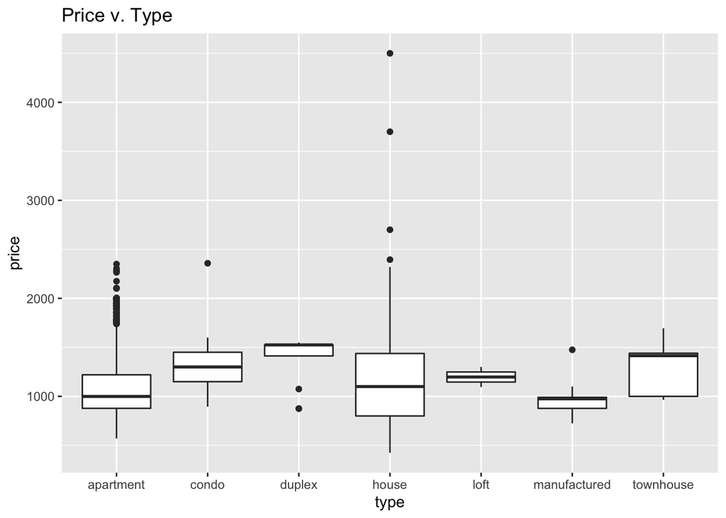

```r
ggplot(housing_cleaned, aes(x=type, y=price)) + geom_boxplot() + ggtitle('Price v. Type')
```

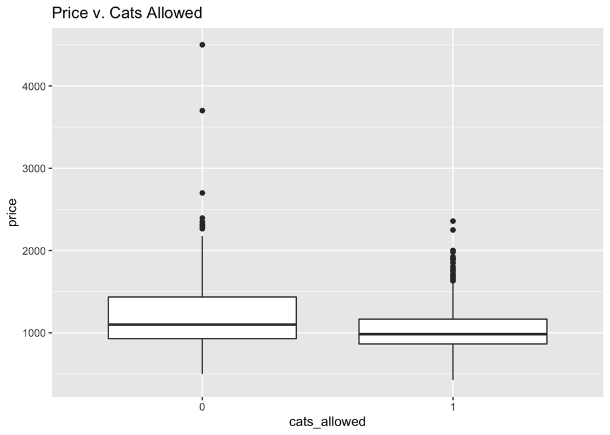

```r
ggplot(housing_cleaned, aes(x=cats_allowed, y=price)) + geom_boxplot() + ggtitle('Price v. Cats Allowed')
```

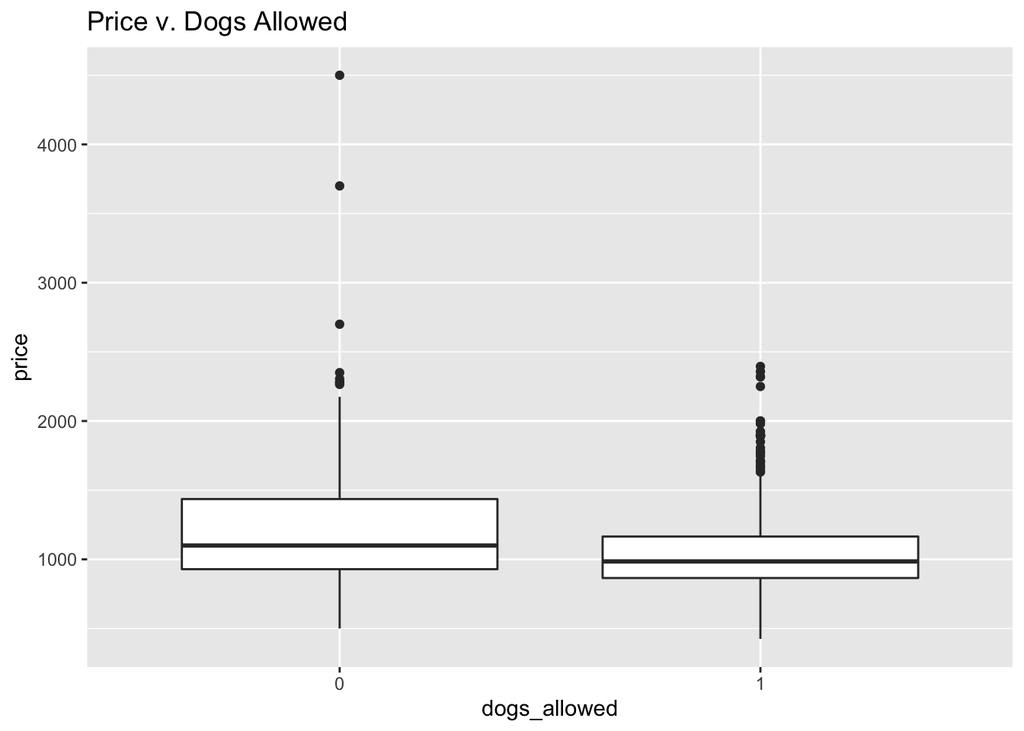

```r
ggplot(housing_cleaned, aes(x=dogs_allowed, y=price)) + geom_boxplot() + ggtitle('Price v. Dogs Allowed')
```

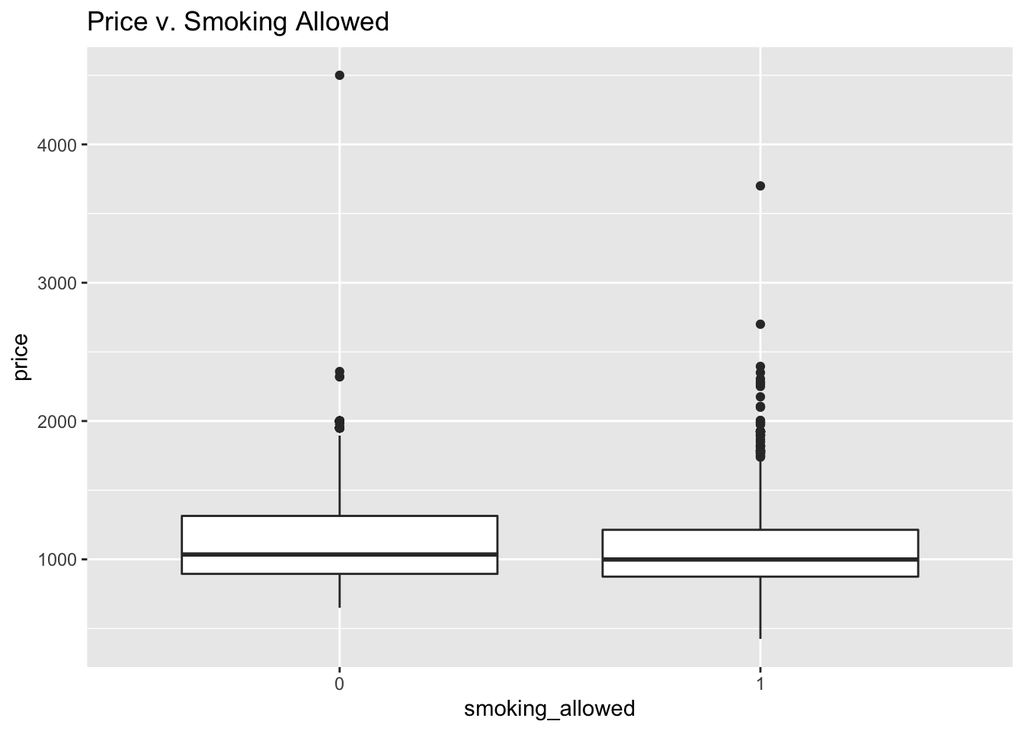

```r
ggplot(housing_cleaned, aes(x=smoking_allowed, y=price)) + geom_boxplot() + ggtitle('Price v. Smoking Allowed')
```

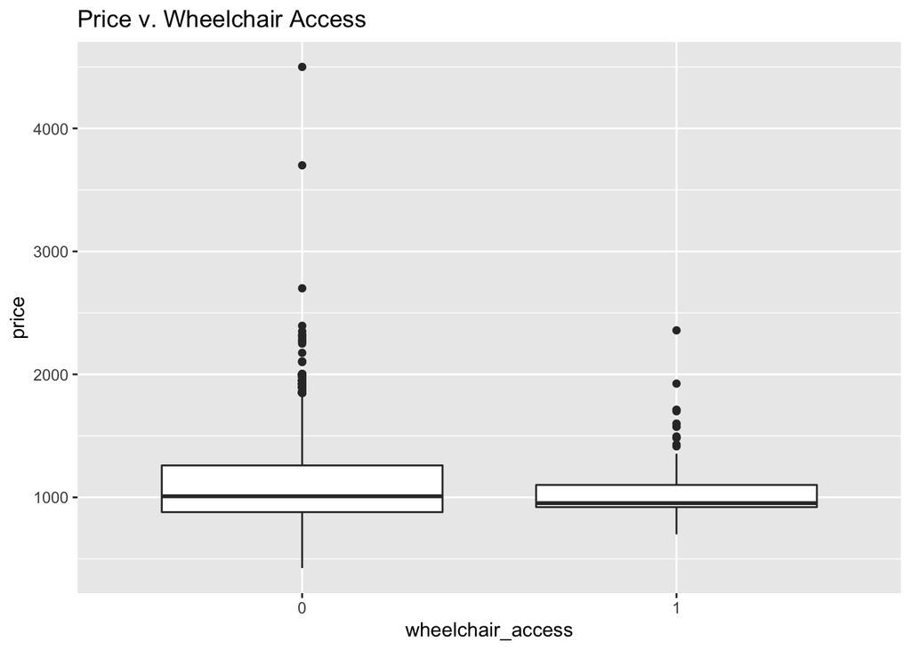

```r
ggplot(housing_cleaned, aes(x=wheelchair_access, y=price)) + geom_boxplot() + ggtitle('Price v. Wheelchair Access')
```

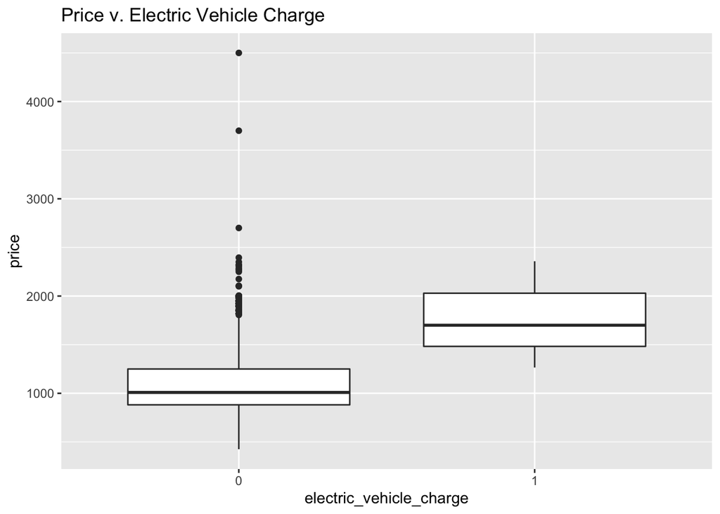

```r
ggplot(housing_cleaned, aes(x=electric_vehicle_charge, y=price)) + geom_boxplot() + ggtitle('Price v. Electric Vehicle Charge')
```

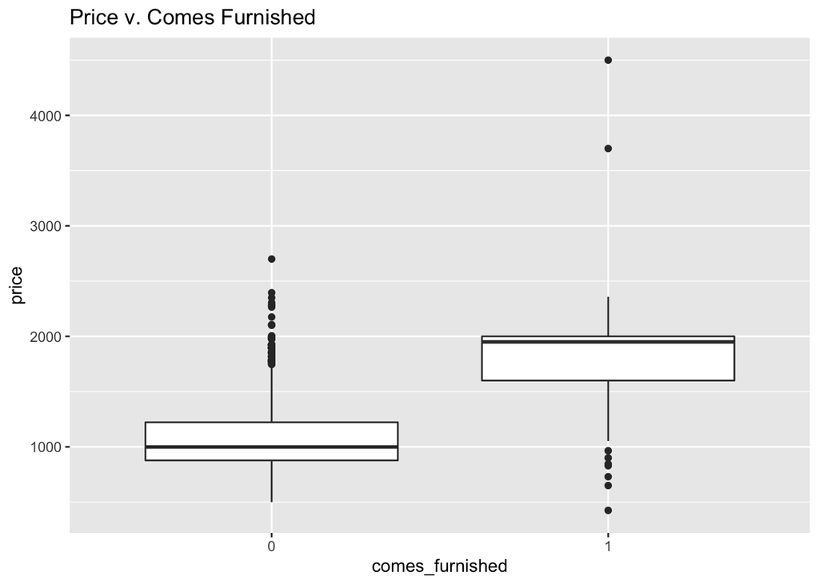

```r
ggplot(housing_cleaned, aes(x=comes_furnished, y=price)) + geom_boxplot() + ggtitle('Price v. Comes Furnished')
```

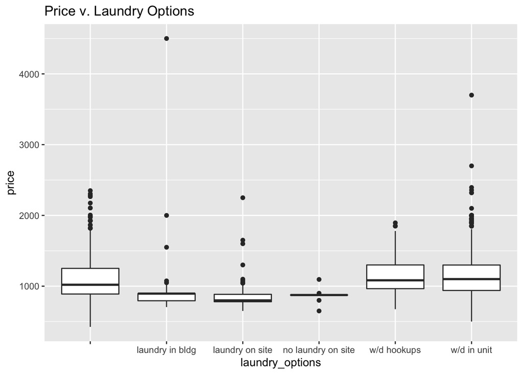

```r
ggplot(housing_cleaned, aes(x=laundry_options, y=price)) + geom_boxplot() + ggtitle('Price v. Laundry Options')
```

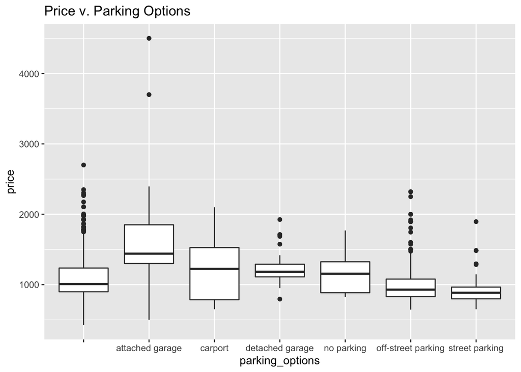

```r
ggplot(housing_cleaned, aes(x=parking_options, y=price)) + geom_boxplot() + ggtitle('Price v. Parking Options')
```

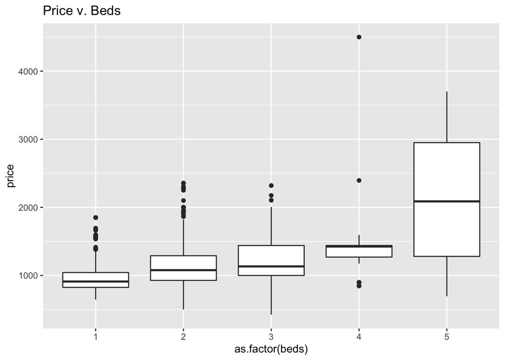

```r
ggplot(housing_cleaned, aes(x=as.factor(beds), y=price)) + geom_boxplot() + ggtitle('Price v. Beds')
```

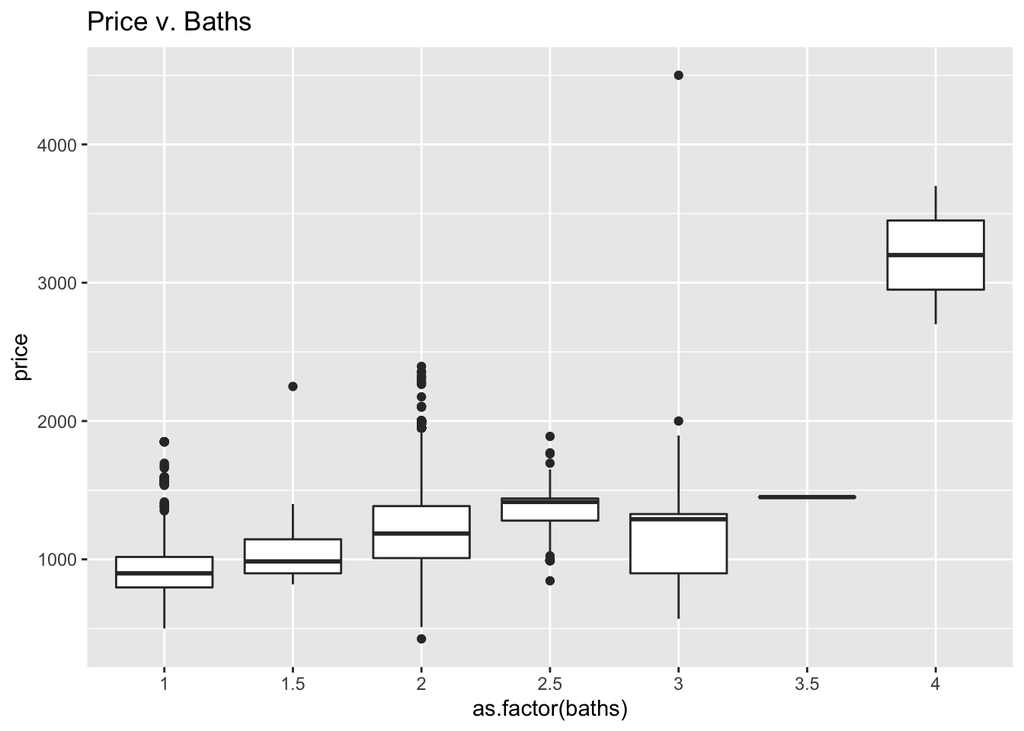

```r
ggplot(housing_cleaned, aes(x=as.factor(baths), y=price)) + geom_boxplot() + ggtitle('Price v. Baths')
```

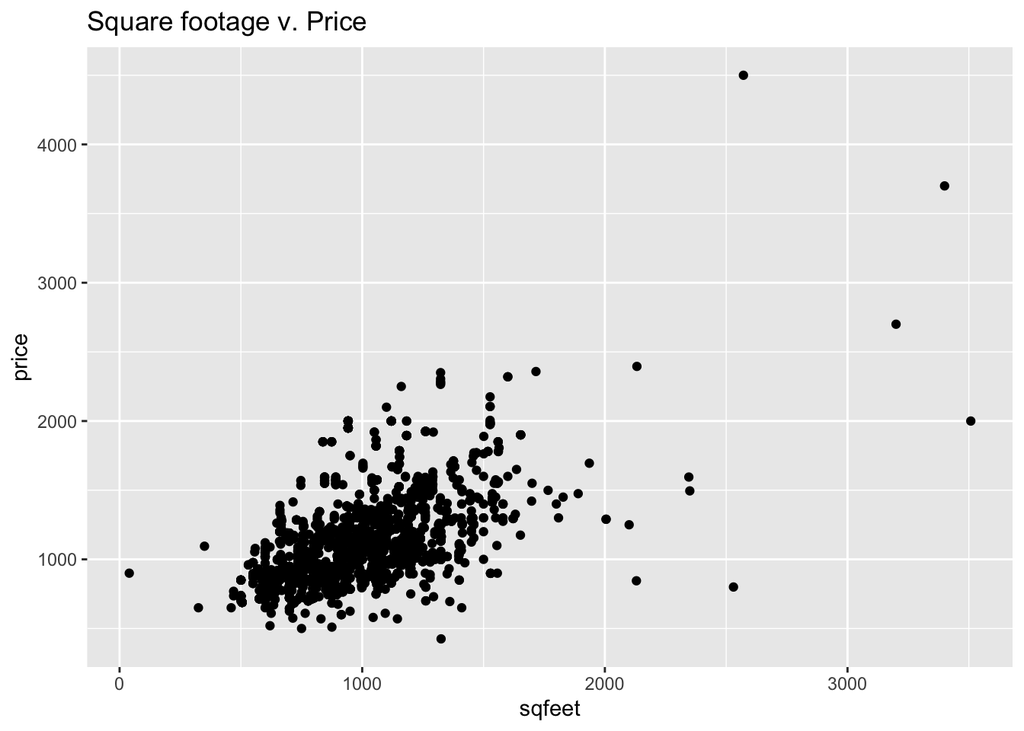

```r
ggplot(housing_cleaned, aes(x=sqfeet, y=price)) + geom_point() + ggtitle('Square footage v. Price')
```

Judging by the bivariate correlations only (without “controlling” for any other predictors), we observe the following:

- Price generally increaes with number of beds
- Price generally increases with number of baths
- Price genereally increases with square footage
- Price varies by property type, e.g. “condos” fetch higher rents than “apartments”
- Prices appear to be higher for listings where pets are *not* allowed
- Prices are lower on listings where smoking is allowed
- Prices are not obviously different for listings with wheelchair access
- Prices are considerably higher for listings with electric vechicle charge
- Prices are higher for furnished vs. unfurnished listings
- Price is higher when a washer/dryer is in-unit/there are in-unit hookups available

## Models - Control variables

As a reminder, our goal in this analysis is to estimate the mean change in expected rental price when a rental property has certain amenities (e.g. in-unit laundry) or allowances, such as dogs. To understand the association of an amnenity such as “in-unit laundry”, it will be important to “control for” things like location, square footage, and beds/baths.

We’ll consider the following variables the “control” variables:  
* beds  
* baths  
* square footage  
* property type

Geographical location is implicitly controlled for, since our data set includes only listings in Jacksonville, FL.

```r
mod_control_variables <- lm(
  price ~
    sqfeet +
    beds +
    baths +
    type,
  data = housing_cleaned)

summary(mod_control_variables)$coefficients
```

```
##                      Estimate   Std. Error    t value      Pr(>|t|)
## (Intercept)       362.9566331  19.20661789  18.897478  1.309378e-74
## sqfeet              0.7492971   0.03100051  24.170478 2.715185e-116
## beds             -184.8098696  12.36308233 -14.948527  1.763621e-48
## baths             221.3950997  14.20268433  15.588257  2.218924e-52
## typecondo          73.4808888  71.13519075   1.032975  3.017143e-01
## typeduplex        310.7827601  71.42036808   4.351458  1.406053e-05
## typehouse         -44.9497296  28.84343512  -1.558404  1.192626e-01
## typeloft          275.3885975 173.56471633   1.586662  1.127142e-01
## typemanufactured -178.2900935  74.75057845  -2.385133  1.714621e-02
## typetownhouse     -39.9181670  34.49240292  -1.157303  2.472579e-01
```

These coefficient estimates are mostly intuitive and expected. The one surprising result is that the coefficients for `beds` is negative - we can see that the direction of the association between `beds` and `price` flips from postivie to negative when we add `sqfeet` to the model.

```r
summary(lm(price ~ beds, data=housing_cleaned))$coefficients
```

```
##             Estimate Std. Error  t value     Pr(>|t|)
## (Intercept) 816.1307  16.066456 50.79718 0.000000e+00
## beds        152.0640   8.190865 18.56507 3.052549e-72
```

```r
summary(lm(price ~ beds + sqfeet, data=housing_cleaned))$coefficients
```

```
##                 Estimate  Std. Error   t value      Pr(>|t|)
## (Intercept)  435.8081737 19.14652241 22.761740 1.650539e-104
## beds        -116.4481657 11.68059781 -9.969367  5.467140e-23
## sqfeet         0.8894279  0.03071817 28.954454 1.675898e-159
```

This could be caused by collinearity, which we check below.

```r
vif(mod_control_variables)
```

```
##           sqfeet             beds            baths        typecondo
##         3.058034         3.363713         2.346071         1.005857
##       typeduplex        typehouse         typeloft typemanufactured
##         1.013938         1.150444         1.001970         1.018544
##    typetownhouse
##         1.084399
```

Although `sqfeet` and `beds` are somewhat correlated, the VIF values of ~3 are acceptable, so the flipping of the sign does not appear to be due to collinearity. The below plot shows what is happening.

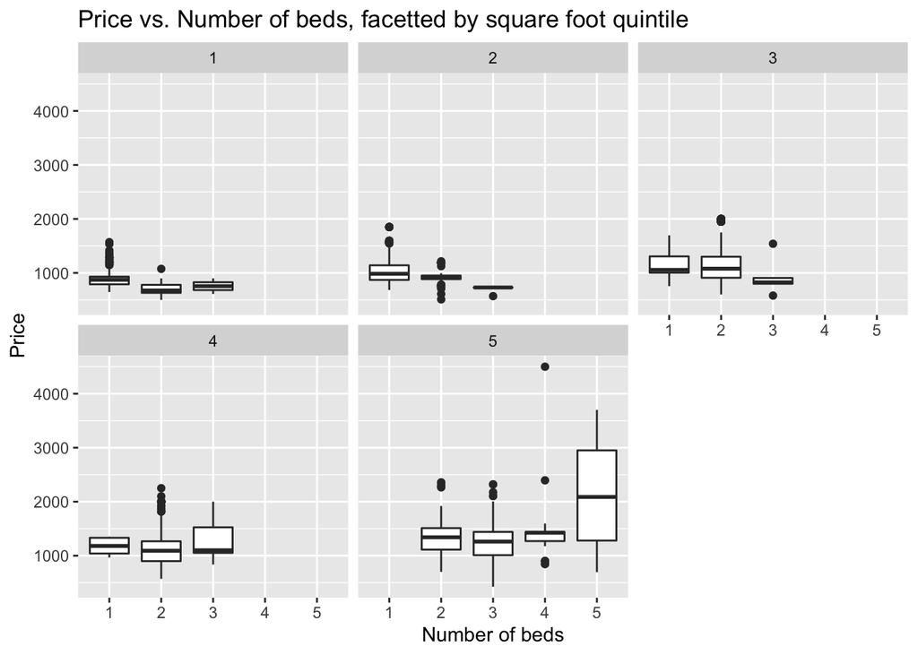

```r
tmp_data_for_plot <- housing_cleaned %>%
  mutate(sq_feet_ntile = ntile(sqfeet, 5)) %>%
  select(sq_feet_ntile,
         sqfeet,
         price,
         beds)

ggplot(tmp_data_for_plot, aes(x=as.factor(beds), y=price)) +
  geom_boxplot() +
  facet_wrap(~as.factor(sq_feet_ntile)) +
  xlab('Number of beds') +
  ylab('Price') +
  ggtitle('Price vs. Number of beds, facetted by square foot quintile')
```

When we facet the price vs. beds by square foot quintile, we see that the number of beds and price are in fact somewhat negatively correlated *within each quintile*. In other words, adding bedrooms while holding square footage constant decreases the price. This is inuitive, in that the size of each indidivudal bedroom becomes smaller, which devalues the property.

## Models - variables of interest

Next we’ll add our variables of interest, and confirm that the inclusion of these models is an improvement over a model with only the “control” variables. In practice, we are asking if certain features/amnenities of a rental listing helps predict price, over only the basic property facts such as square footage, number of beds, etc.

We’ll compare three models: 1) the “control” model, 2) a “full” model that includes all of the variables available (control + varibles of interest), and 3) the result of applying a backwards stepwise procedure on the “full” model.

```r
control_model = lm(
  log(price) ~
    sqfeet +
    beds +
    baths +
    type,
  data = housing_cleaned)

full_model = lm(
  log(price) ~
    type +
    sqfeet +
    beds +
    baths +
    cats_allowed +
    dogs_allowed +
    smoking_allowed +
    wheelchair_access +
    electric_vehicle_charge +
    comes_furnished +
    laundry_options +
    parking_options,
  data = housing_cleaned)

selected_model = step(full_model, direction = "backward", trace=FALSE)

control_model_stats = c("Adj. R2" = summary(control_model)$adj.r.squared)
full_model_stats = c("Adj. R2" = summary(full_model)$adj.r.squared)
selected_model_stats = c("Adj. R2" = summary(selected_model)$adj.r.squared)

kable(
  data.frame("Control Model" = control_model_stats,
             "Full Model" = full_model_stats,
             "Selected Model" = selected_model_stats),
  format = "markdown",
  col.names = c("Control Model", "Full Model", "Selected Model"))
```

|  | Control Model | Full Model | Selected Model |
| --- | --- | --- | --- |
| Adj. R2 | 0.4300452 | 0.6142985 | 0.6145316 |

# Results

```r
summary(selected_model)
```

```
##
## Call:
## lm(formula = log(price) ~ type + sqfeet + beds + baths + cats_allowed +
##     comes_furnished + laundry_options + parking_options, data = housing_cleaned)
##
## Residuals:
##      Min       1Q   Median       3Q      Max
## -1.03747 -0.09697 -0.01770  0.08828  0.83910
##
## Coefficients:
##                                     Estimate Std. Error t value Pr(>|t|)
## (Intercept)                        6.484e+00  1.410e-02 459.855  < 2e-16 ***
## typecondo                         -2.161e-02  4.814e-02  -0.449 0.653457
## typeduplex                         2.245e-01  5.462e-02   4.111 4.06e-05 ***
## typehouse                         -2.360e-01  1.952e-02 -12.088  < 2e-16 ***
## typeloft                           2.823e-01  1.178e-01   2.395 0.016680 *
## typemanufactured                  -1.117e-01  5.001e-02  -2.233 0.025645 *
## typetownhouse                     -9.609e-02  2.325e-02  -4.133 3.70e-05 ***
## sqfeet                             5.492e-04  2.101e-05  26.134  < 2e-16 ***
## beds                              -8.790e-02  8.528e-03 -10.307  < 2e-16 ***
## baths                              9.384e-02  1.015e-02   9.244  < 2e-16 ***
## cats_allowed1                     -6.397e-02  9.322e-03  -6.863 8.46e-12 ***
## comes_furnished1                   2.471e-01  2.114e-02  11.686  < 2e-16 ***
## laundry_optionslaundry in bldg    -1.598e-01  2.899e-02  -5.513 3.88e-08 ***
## laundry_optionslaundry on site    -1.631e-01  1.394e-02 -11.697  < 2e-16 ***
## laundry_optionsno laundry on site -9.717e-02  5.490e-02  -1.770 0.076827 .
## laundry_optionsw/d hookups        -4.178e-02  1.215e-02  -3.437 0.000597 ***
## laundry_optionsw/d in unit         3.321e-02  1.087e-02   3.055 0.002271 **
## parking_optionsattached garage     1.868e-01  1.433e-02  13.035  < 2e-16 ***
## parking_optionscarport             8.307e-02  4.153e-02   2.000 0.045580 *
## parking_optionsdetached garage     1.178e-01  2.142e-02   5.498 4.22e-08 ***
## parking_optionsno parking          4.954e-02  2.249e-02   2.203 0.027705 *
## parking_optionsoff-street parking  9.097e-03  9.104e-03   0.999 0.317790
## parking_optionsstreet parking     -4.001e-02  1.778e-02  -2.250 0.024543 *
## ---
## Signif. codes:  0 '***' 0.001 '**' 0.01 '*' 0.05 '.' 0.1 ' ' 1
##
## Residual standard error: 0.1615 on 2515 degrees of freedom
## Multiple R-squared:  0.6179, Adjusted R-squared:  0.6145
## F-statistic: 184.8 on 22 and 2515 DF,  p-value: < 2.2e-16
```

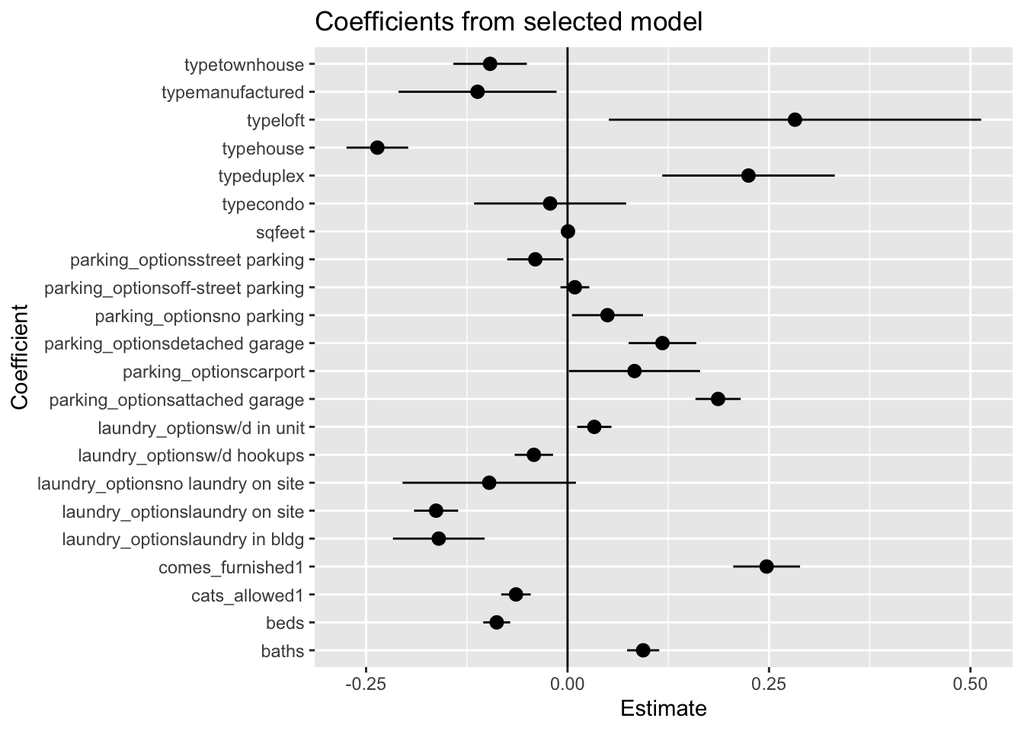

```r
coef_plot_data <- tidy(selected_model) %>%
  mutate(
    ymin = estimate - (qnorm(1 - 0.05 / 2) * std.error),
    ymax = estimate + (qnorm(1 - 0.05 / 2) * std.error)) %>%
  filter(term != '(Intercept)')

ggplot(coef_plot_data, aes(x=term, y=estimate)) +
  geom_hline(yintercept=0) +
  geom_pointrange(aes(ymin=ymin, ymax=ymax)) +
  labs(x="Coefficient", y="Estimate", title="Coefficients from selected model") +
  coord_flip()
```

# Discussion

We have establised that certain “features/amnenties” of a rental listing are significantly associated with price. Knowing this information helps us predict/explain price, beyond knowing the basics such as square footage, number of beds/baths, etc.

This has numerous practical implications. One is that a property owner/landlord can increase the value of their rental listing (i.e. raise rent) by improvements such as in-unit laundry, improving parking options through a garage or carport etc. They can use the coefficient estimates in a cost/benefit analysis.

From a renters perspective, they can estimate how much additional rent they would expect to pay if requiring (for example) a furnished rental.

The four feature/amnenity variables that are not included in the final model are `dogs_allowed`, `smoking_allowed`, `wheelchair_access`, and `electric_vehicle_charge`. Based on our earlier exploratory analysis, we suspect `dogs_allowed` was not selected due to being fairly collinear with `cats_allowed`, and `electric_vehicle_charge` was not selected due to having only a handful of observations for listings with electric vehicle charges.